# Asiye Demir Project A

Asiye Demir

01/30/2021

### Description

Gun violence or ownership has been a ongoing debate in the United States. Although the legal debate and regulations have changed over time, a gun can be a reason for somebody’s death. In this report, I will examine the gun deaths in America by looking at the proportions in the intention, gender and race factors behind the gun death across years.

Data Source: [Centers for Decease Control and Prevention](https://www.cdc.gov/nchs/data_access/VitalStatsOnline.htm#Mortality_Multiple)

### Analysis

As a first step, I looked the proportions in the intent of gun death in 2012. As Table 1 and Figure 1 show, the most indented reason for gun use is suicide (.62) in 2012. Using a gun for homicidal purpose has the second place with .36 proportion.

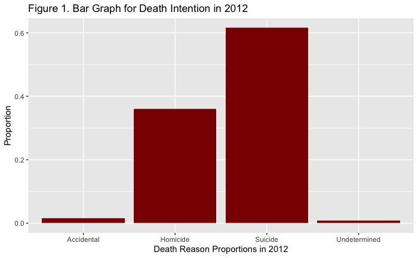

Table 1. Proportions for Intent of Gun Death in 2012

| intent | freq | prop |
| --- | --- | --- |
| Accidental | 548 | 0.0163 |
| Homicide | 12093 | 0.3603 |
| Suicide | 20666 | 0.6157 |
| Undetermined | 256 | 0.0076 |

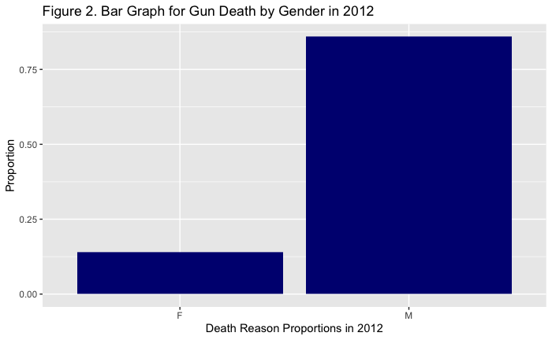

Gun death in 2012 was observed mostly among men than women. Men constitutes 86% of the sample while women constitutes only 14%.

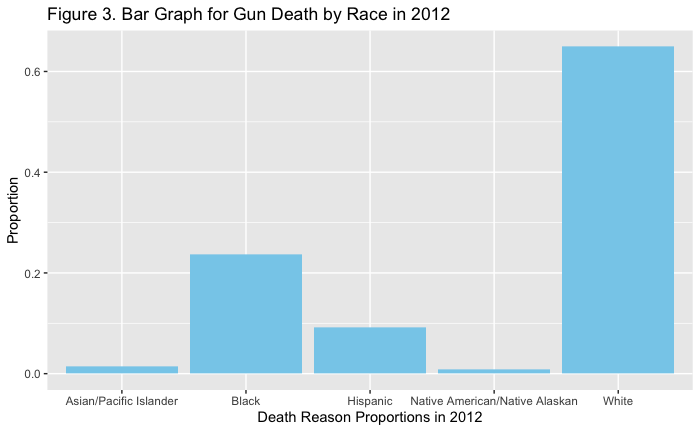

Table 3. Proportions for Gun Death by Race in 2012

| race | freq | prop |
| --- | --- | --- |
| Asian/Pacific Islander | 453 | 0.01350 |
| Black | 7946 | 0.23675 |
| Hispanic | 3061 | 0.09120 |
| Native American/Native Alaskan | 310 | 0.00924 |
| White | 21793 | 0.64932 |

The last variable of interest in my report is race frequency in the gun death in 2012. Among 5 different race class, white death due to gun is overwhelmingly high. (.65). More than half of the gun death cases contain white people. Black people follows white frequency with about .25. Remaining 10 percent is shared among Asian, Native American and Hispanic people.

### Conclusion

The gun death in 2012 varies depending on the variable of interest. When I looked at the intention behind gun use, the most observed intention seems to be suicide with .62 rate. Homicide follows this ratio with .36. Gun death might have happened accidentally in .016 rate while we also have undetermined reasons in .007. Aligning with the common sense men committed gun death more than women in 2012. While 86% of men died by gun, this ratio for women is 14%.

### Description

In the second part of the report, I will analyze the same variable of interests; intent, gender and race, in the 2019 data set.

### Analysis

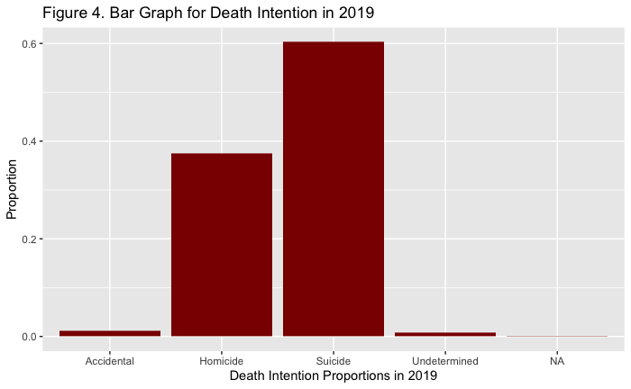

Table 3. Proportions for Intent of Gun Death in 2019

| intent | freq | prop |
| --- | --- | --- |
| Accidental | 486 | 0.0122 |
| Homicide | 14909 | 0.3755 |
| Suicide | 23941 | 0.6029 |
| Undetermined | 346 | 0.0087 |
| NA | 25 | 0.0006 |

Like 2012, in 2019 gun death for suicidal tendencies was in the first place. Likewise, homicide follows suicide with .37.

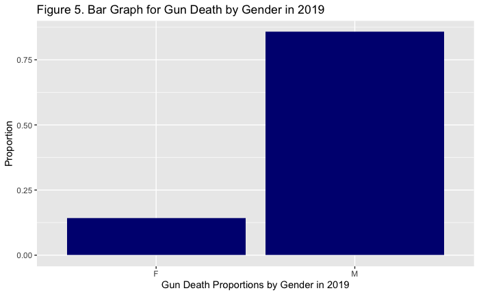

In 2019, gun death by gender has not been changed much from 2012. Gun death among men is observed overwhelmingly more than gun death among women. .86 of men died due to guns in 2019 while this ratio is .14 for women.

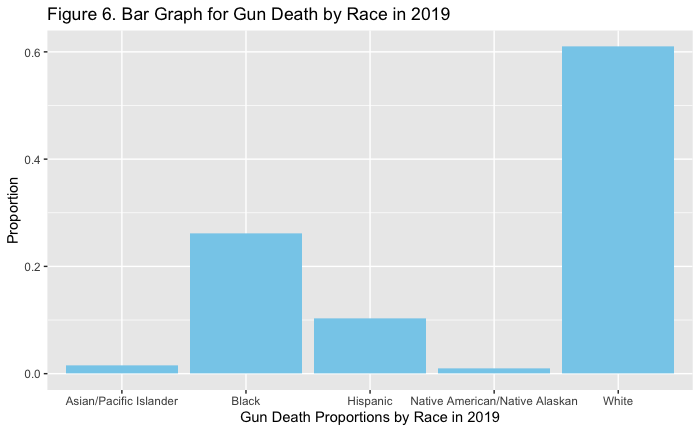

Table 4. Proportions for Gun Death by Race in 2019

| race | freq | prop |
| --- | --- | --- |
| Asian/Pacific Islander | 641 | 0.0161 |
| Black | 10410 | 0.2622 |
| Hispanic | 4058 | 0.1022 |
| Native American/Native Alaskan | 386 | 0.0097 |
| White | 24212 | 0.6098 |

For the race variable in 2019, white people has still the dominant ratio in the frequency with .61. Similarly, Black people follows white people with .26. Remaining 13% has been shared among Asian, Hispanic and Native American people.

I will continue to comparison of these two years together in the following part of the report.

[figure not shown]

| year | intent | freq | prop |
| --- | --- | --- | --- |
| 2012 | Accidental | 548 | 0.5299807 |
| 2012 | Homicide | 12093 | 0.4478557 |
| 2012 | Suicide | 20666 | 0.4632905 |
| 2012 | Undetermined | 256 | 0.4252492 |
| 2019 | Accidental | 486 | 0.4700193 |
| 2019 | Homicide | 14909 | 0.5521443 |
| 2019 | Suicide | 23941 | 0.5367095 |
| 2019 | Undetermined | 346 | 0.5747508 |
| 2019 | NA | 25 | 1.0000000 |

[figure not shown]

| year | race | freq | prop |
| --- | --- | --- | --- |
| 2012 | Asian/Pacific Islander | 453 | 0.4140768 |
| 2012 | Black | 7946 | 0.4328830 |
| 2012 | Hispanic | 3061 | 0.4299761 |
| 2012 | Native American/Native Alaskan | 310 | 0.4454023 |
| 2012 | White | 21793 | 0.4737094 |
| 2019 | Asian/Pacific Islander | 641 | 0.5859232 |
| 2019 | Black | 10410 | 0.5671170 |
| 2019 | Hispanic | 4058 | 0.5700239 |
| 2019 | Native American/Native Alaskan | 386 | 0.5545977 |
| 2019 | White | 24212 | 0.5262906 |

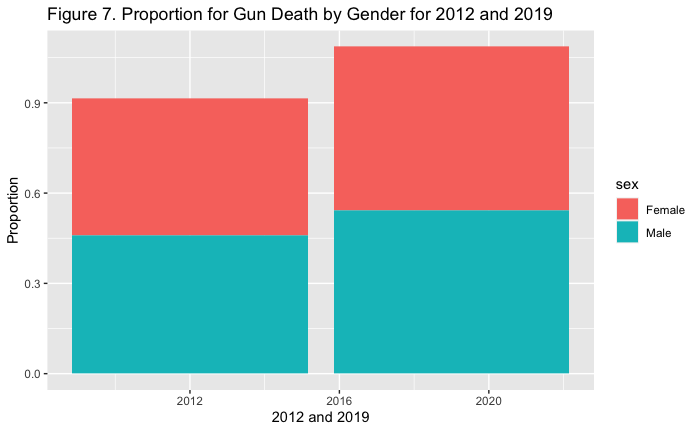

| year | sex | freq | prop |
| --- | --- | --- | --- |
| 2012 | F | 4725 | 0.4547204 |
| 2012 | M | 28838 | 0.4586269 |
| 2019 | F | 5666 | 0.5452796 |
| 2019 | M | 34041 | 0.5413731 |